# Analysis of Variance on State-level Government Intervention

Kenneth Lee

15/09/2020

## Data Preprocessing

```r
library(ggplot2)
library (readr)
library(tidyverse)
library(dplyr)
library(covidcast)
library(lubridate)
library(ggpubr)
library(reshape2)
library(tidyr)
library(viridis)
library(gridExtra)
library(zoo)
library(cowplot)
library(gplots)
library(car)

source("code/painter.r")
source("code/load_all_data.r")
```

```r
STARTDATE <- "2020-02-20"
ENDDATE <- lubridate::today()
GEO_TYPE = "state" # state-level
GEO_VALUE = "*" # all states
EXCLUDED_AREAS = c("as","gu", "mp","vi") # excluded areas due to small sample size
DT_X = 7 #   Time shifts to consider for x
```

```r
data <- load_data(STARTDATE, ENDDATE, GEO_TYPE, GEO_VALUE, EXCLUDED_AREAS)

# Read government intervention data
urlfile="https://raw.githubusercontent.com/COVID19StatePolicy/SocialDistancing/master/data/USstatesCov19distancingpolicy.csv"
policy <- read_csv(url(urlfile))
```

```r
# Convert to lower case
policy$StatePostal <- tolower(policy$StatePostal)
# First we convert the date to a proper format
policy[, c("DateIssued", "DateEnacted", "DateExpiry" ,"DateEased", "DateEnded", "DateReexpanded1", "DateReeased1")] <- data.frame(lapply(policy[, c("DateIssued", "DateEnacted", "DateExpiry" ,"DateEased", "DateEnded", "DateReexpanded1", "DateReeased1")], function(x) as.Date(as.character(x), "%Y%m%d")))

# How many unique policy per state for each policy?
state.policy <- policy %>% filter(StateWide == 1)
```

## Explore the variability of policy across states

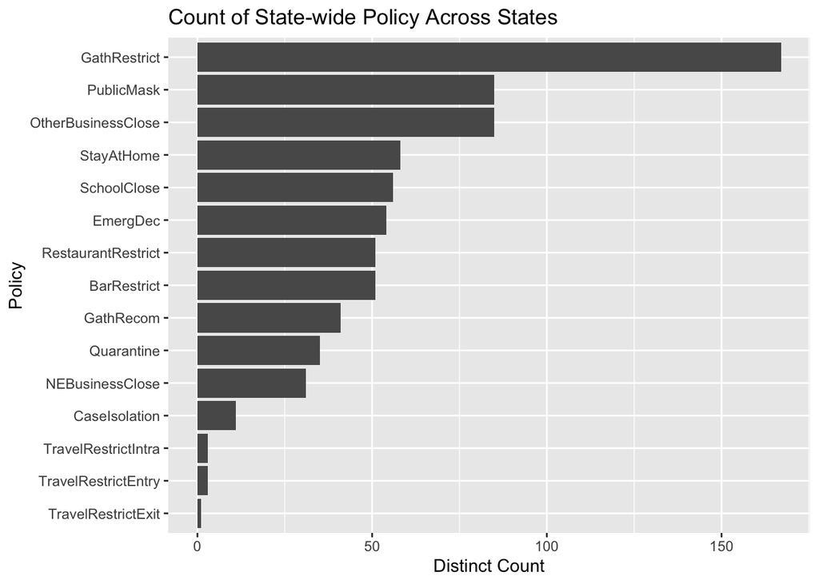

```r
# Plot for non-distinct count and mandate distribution
policy.by.state <- state.policy[,c("StateName","StatePolicy", "Mandate")]
# Get the count
new_counts <- table(policy.by.state$StatePolicy, policy.by.state$Mandate)

# Convert to data frame
new_counts.df <- as.data.frame(new_counts)
# Change the colname for the future legend readibility
colnames(new_counts.df)[2] <- "Mandate?"

# Plot the graph for the count
p <- ggplot(new_counts.df,aes(x= reorder(Var1,Freq),Freq)) +
  geom_bar(stat ="identity")+
  coord_flip()+
  labs(title = "Count of State-wide Policy Across States", y="Distinct Count", x="Policy")
p
```

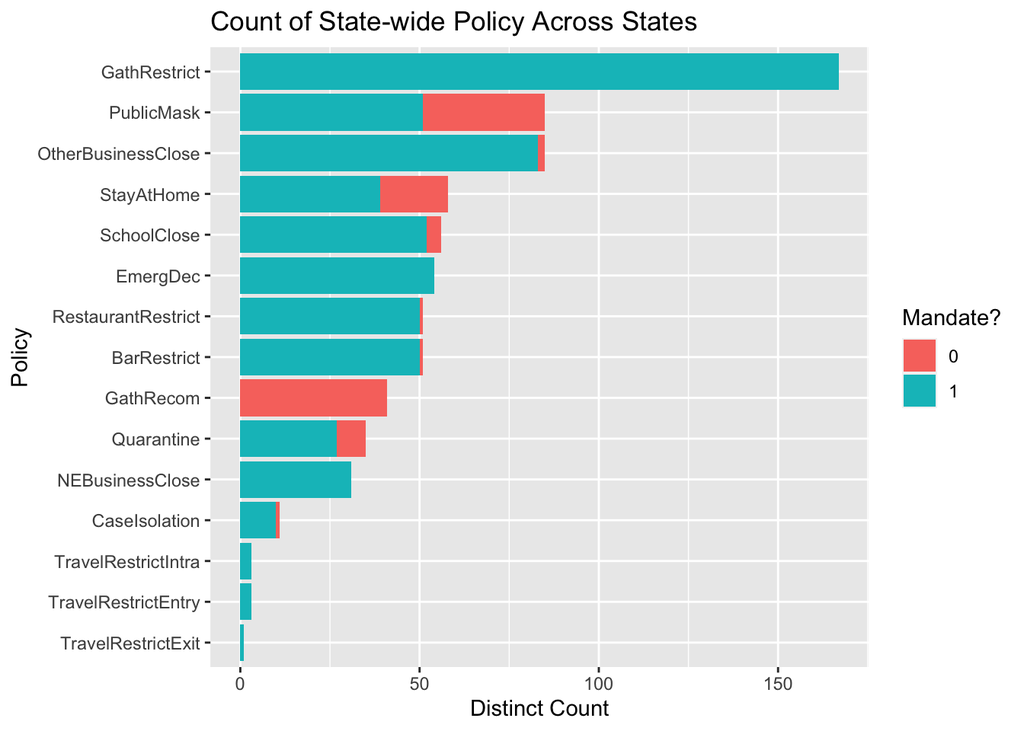

```r
# Show the difference by Mandate?
p <- ggplot(new_counts.df,aes(x= reorder(Var1,Freq),Freq, fill = `Mandate?`)) +
  geom_bar(stat ="identity")+
  coord_flip()+
  labs(title = "Count of State-wide Policy Across States", y="Distinct Count", x="Policy")+
   guides(fill=guide_legend(title="Mandate?"))
p
```

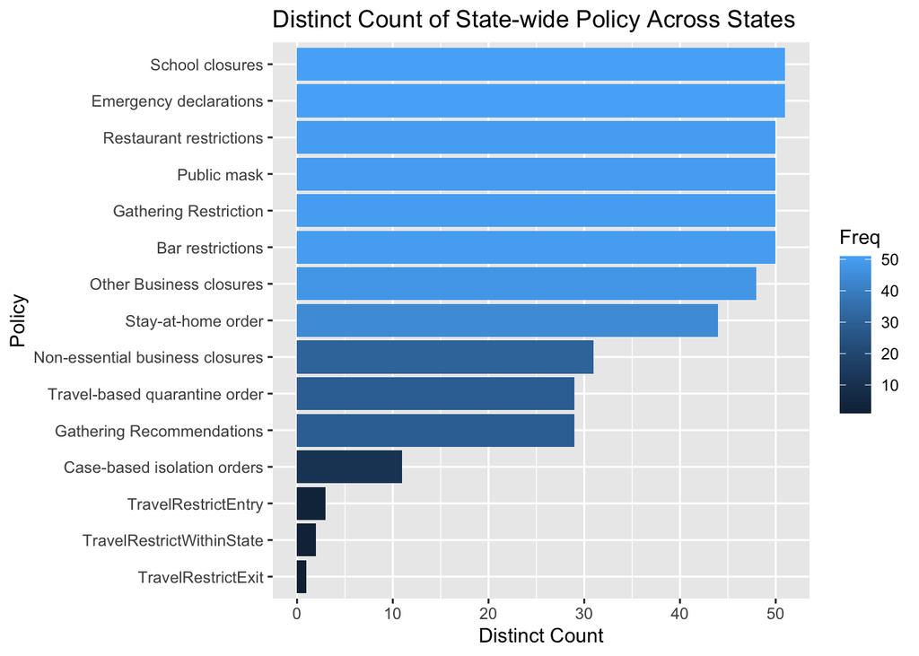

```r
# Filter the dataframe by distrinct rows
unique.policy.by.state <- distinct(state.policy[,c("StateName","StatePolicy")])
# Get the count
counts <- table(unique.policy.by.state$StatePolicy)

# Convert to data frame
counts.df <- as.data.frame(counts)

# Rename the policy for better readibility
counts.df[,"Var1"] <- c("Bar restrictions", "Case-based isolation orders", "Emergency declarations", "Gathering Recommendations", "Gathering Restriction", "Non-essential business closures", "Other Business closures", "Public mask", "Travel-based quarantine order", "Restaurant restrictions", "School closures", "Stay-at-home order", "TravelRestrictEntry", "TravelRestrictExit", "TravelRestrictWithinState")

# Plot the graph for ditinct count
p <- ggplot(counts.df,aes(x= reorder(Var1,Freq),Freq, fill=Freq))+
  geom_bar(stat ="identity")+
  coord_flip()+
  labs(title = "Distinct Count of State-wide Policy Across States", y="Distinct Count", x="Policy")

p
```

## Construct government intervention signal over time

We may construct a simple signal to represent state-wide government intervention over time. To do so, we count the number of policies that has been enacted in a day and take the average number within 7 days as an intervention signal.

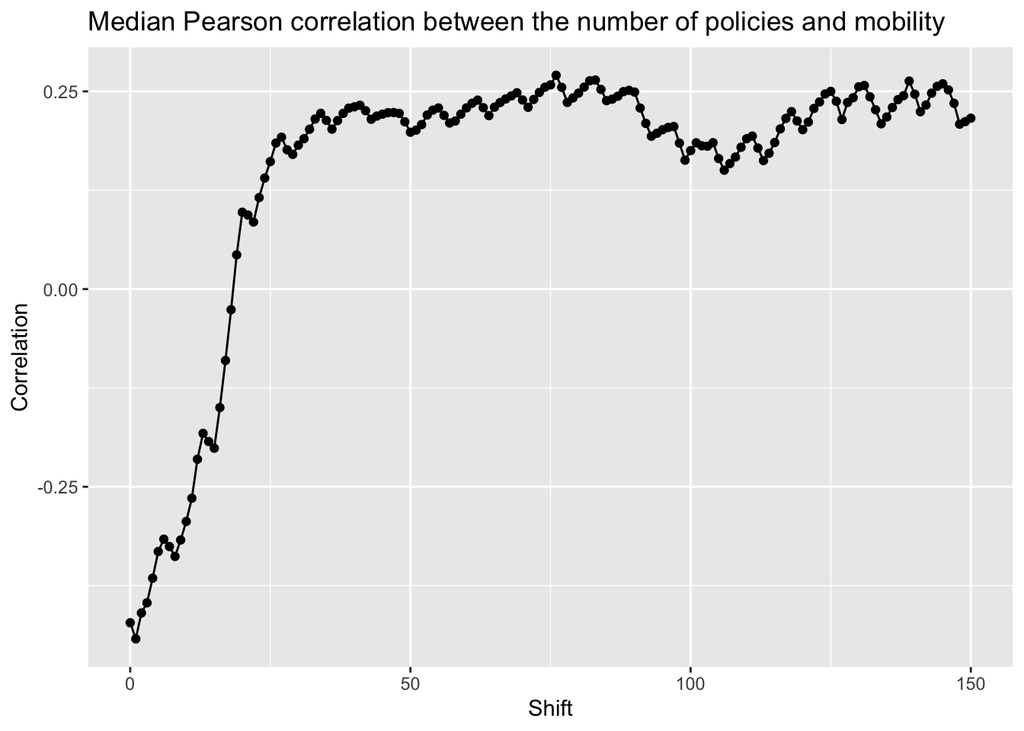

```r
# Get the dates between start and end date
all.dates <- seq(as.Date(STARTDATE), as.Date(ENDDATE), by="days")
time_value <- sort(rep(all.dates, length(unique(policy$StatePostal)) ))

# Generate geo_value
geo_value <- rep(unique(policy$StatePostal), length(all.dates))
policy_signal <- data.frame(time_value = time_value, geo_value = geo_value)

# Create empty columns
policy_signal[,unique(policy$StatePolicy)] <- 0

# Fill in the count for each date
  # Get the policy name and state to filer policy signal
for (row in (1:nrow(policy))){
  current.policy <- policy[row,]$StatePolicy
  current.state <- policy[row,]$StatePostal
  if (is.na(policy[row,]$DateEnded)){
    # Filter the rows of dataframe to be the current state and the time value that is after the policy is enacted.
    policy_signal[policy_signal$geo_value == current.state & policy_signal$time_value > as.Date(policy[row,]$DateEnacted), current.policy] <- 1
  }else{
    # Get time range between Date Enacted and Date Ended
    time.range <- seq(as.Date(policy[row,]$DateEnacted), as.Date(policy[row,]$DateEnded), by = "days")

    # Fill in the the rows that are in the current policy and fall between the time arrange to be 1
    policy_signal[policy_signal$time_value %in% time.range & policy_signal$geo_value == current.state, current.policy] <- 1
    }
}

# Compute the sum of the number of policies for every day in the state
policy_signal$total.num.policy <- rowSums(policy_signal[unique(policy$StatePolicy)])

# Compute the average on a 7day sliding window
policy_signal <-policy_signal %>%
    arrange(desc(geo_value)) %>%
    group_by(geo_value) %>%
    mutate(num.policy.7avg = rollmean(total.num.policy, k = 7, fill = NA))%>%
    ungroup()

# Finalize the covidcast-like signal for governemnt intervention
covidcast.like.policy.signal <- policy_signal %>% transmute(
  geo_value = geo_value,
  signal = "policy_7dav_num",
  time_value = time_value,
  direction = NA,
  issue = lubridate::today(),
  lag = issue - time_value,
  value = num.policy.7avg,
  stderr = NA,
  sample_size = NA,
  data_source = 'University of Washington')

# Pearson correlation between the number of policies and mobility across states
pearson_policy <- getCorrByShift(150, covidcast.like.policy.signal, data$Full.Time.Mobility, "pearson")

pearson_policy_med <-  getMedian(pearson_policy)

# plot the graph
p <- ggplot(pearson_policy_med , aes(x = dt, y = median)) + geom_line() + geom_point() + labs(title = "Median Pearson correlation between the number of policies and mobility", x = "Shift", y = "Correlation") +
  theme(legend.title = element_blank())

p
```

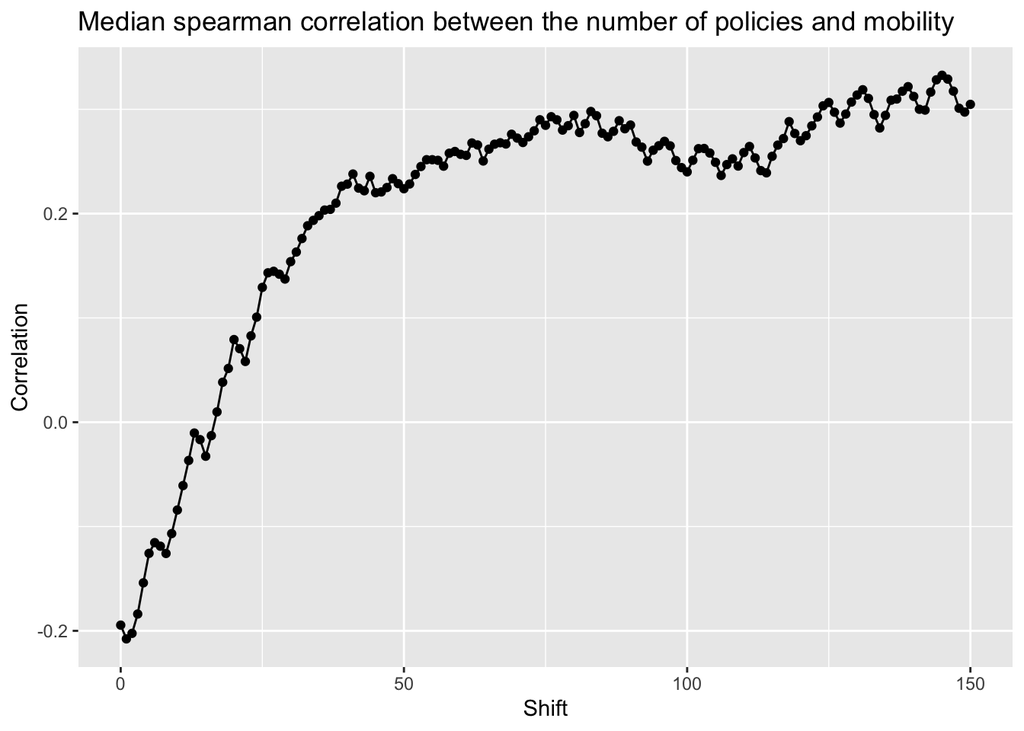

```r
# Spearman correlation between the number of policies and mobility across states
spearman_policy <- getCorrByShift(150, covidcast.like.policy.signal,data$Full.Time.Mobility, "spearman")

spearman_policy_med <-  getMedian(spearman_policy)

s<- ggplot(spearman_policy_med, aes(x = dt, y = median)) + geom_line() + geom_point() + labs(title = "Median spearman correlation between the number of policies and mobility", x = "Shift", y = "Correlation") +
  theme(legend.title = element_blank())
s
```

## Correlation across states over different day shift

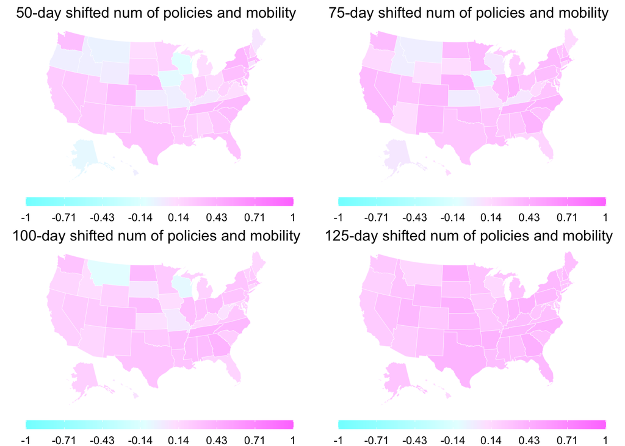

```r
# Set a bunch of fields so that the data frame knows how to plot itself
ls = list()
idx <- seq(50,125,25)
count <- 1
for (i in idx){
  policy.mobility.cor <- covidcast_cor(covidcast.like.policy.signal, data$Full.Time.Mobility, by = "geo_value", dt_x = i, method = "spearman")

  policy.mobility.cor$time_value = STARTDATE
  policy.mobility.cor$issue = STARTDATE
  attributes(policy.mobility.cor)$geo_type = "state"
  class(policy.mobility.cor) = c("covidcast_signal", "data.frame")

# Plot choropleth maps, using the covidcast plotting functionality
ls[[count]]  <-plot(policy.mobility.cor, title = sprintf("%s-day shifted num of policies and mobility", i), range = c(-1, 1), choro_col = cm.colors(10), alpha = 0.4)
count <- count + 1
}

# Plot all graphs
do.call(grid.arrange,ls)
```

## Distribution of mobility by various intervention across states

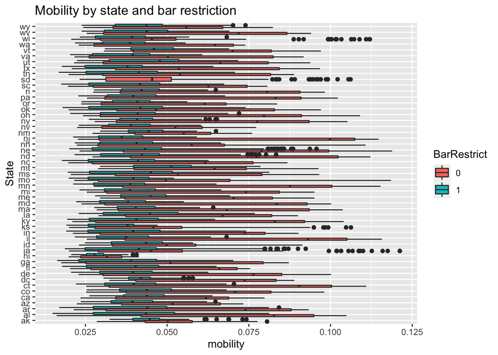

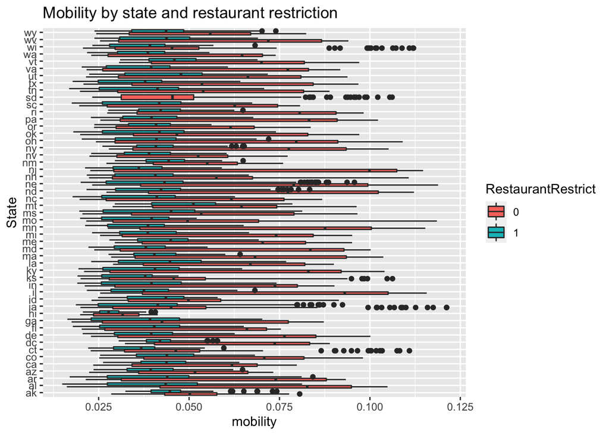

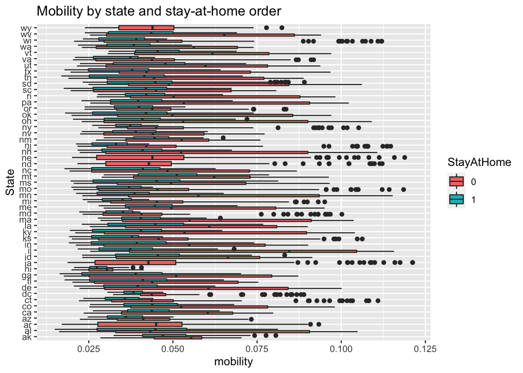

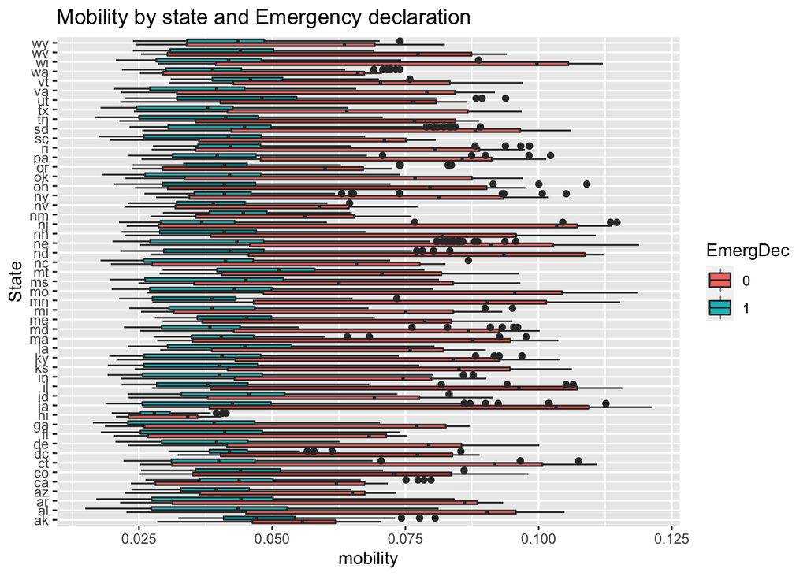

## Treatment effect of government interventions

Moreover, we may be interested to know the following:

- Is there a difference in the means of mobility signal across state?
- Is there a difference in the means of mobility signal in terms of stay-at-home order?
- Is there an interaction between the factor of states and the factor of the order?

To answer these questions, assuming that the data are normally distributed and the variance across groups are homogeneous, we will use ANOVA (Analysis of Variance). We will check these assumptions in the model diagnostics.

### Main effect of States

We can see that some states have a particularly higher range of the mean mobility signal. For example, Montana (MT) clearly stands out from the rest, whereas Hawaii (HI) has a much lower mean mobility signal from Feb. to Sep. in 2020. h

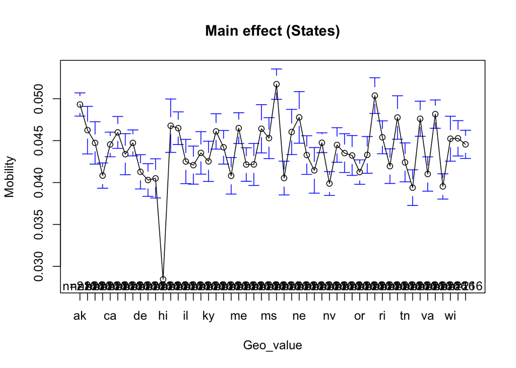

```r
# Plotting the main effect of geo_value
plotmeans(value.x~geo_value,data=intervention_mobility_case, xlab="Geo_value", ylab="Mobility", main="Main effect (States)")
```

### Correlation of the residuals from two linear regression models

```r
# Plot the correlation between residuals given by two linear regression models

# model 0 : include only (X1) states, (X2) stayhome signal, (y) mobility
lm.fit.0 <- lm(value.x ~ as.factor(StayAtHome)+as.factor(geo_value), data=factored_data)
summary(lm.fit.0)
```

```
##
## Call:
## lm(formula = value.x ~ as.factor(StayAtHome) + as.factor(geo_value),
##     data = factored_data)
##
## Residuals:
##       Min        1Q    Median        3Q       Max
## -0.040360 -0.010595 -0.000382  0.006835  0.074425
##
## Coefficients:
##                          Estimate Std. Error t value Pr(>|t|)
## (Intercept)             0.0603354  0.0011039  54.657  < 2e-16 ***
## as.factor(StayAtHome)1 -0.0129405  0.0003918 -33.029  < 2e-16 ***
## as.factor(geo_value)al -0.0037823  0.0014882  -2.541 0.011053 *
## as.factor(geo_value)ar -0.0156070  0.0015251 -10.234  < 2e-16 ***
## as.factor(geo_value)az -0.0166891  0.0015087 -11.062  < 2e-16 ***
## as.factor(geo_value)ca -0.0045888  0.0014881  -3.084 0.002050 **
## as.factor(geo_value)co -0.0035102  0.0014881  -2.359 0.018350 *
## as.factor(geo_value)ct -0.0134195  0.0015053  -8.915  < 2e-16 ***
## as.factor(geo_value)dc -0.0120726  0.0015053  -8.020 1.16e-15 ***
## as.factor(geo_value)de -0.0080922  0.0014881  -5.438 5.50e-08 ***
## as.factor(geo_value)fl -0.0096711  0.0014882  -6.498 8.47e-11 ***
## as.factor(geo_value)ga -0.0089359  0.0014881  -6.005 1.97e-09 ***
## as.factor(geo_value)hi -0.0234257  0.0014901 -15.721  < 2e-16 ***
## as.factor(geo_value)ia -0.0135562  0.0015251  -8.889  < 2e-16 ***
## as.factor(geo_value)id -0.0026500  0.0014881  -1.781 0.074969 .
## as.factor(geo_value)il -0.0066818  0.0014881  -4.490 7.19e-06 ***
## as.factor(geo_value)in -0.0073549  0.0014881  -4.943 7.83e-07 ***
## as.factor(geo_value)ks -0.0133257  0.0015055  -8.851  < 2e-16 ***
## as.factor(geo_value)ky -0.0070211  0.0014881  -4.718 2.41e-06 ***
## as.factor(geo_value)la -0.0032116  0.0014881  -2.158 0.030932 *
## as.factor(geo_value)ma -0.0052260  0.0014881  -3.512 0.000447 ***
## as.factor(geo_value)md -0.0167148  0.0015087 -11.079  < 2e-16 ***
## as.factor(geo_value)me -0.0034203  0.0014882  -2.298 0.021563 *
## as.factor(geo_value)mi -0.0139927  0.0015024  -9.314  < 2e-16 ***
## as.factor(geo_value)mn -0.0074510  0.0014881  -5.007 5.61e-07 ***
## as.factor(geo_value)mo -0.0121815  0.0015144  -8.044 9.61e-16 ***
## as.factor(geo_value)ms -0.0045523  0.0014882  -3.059 0.002226 **
## as.factor(geo_value)mt  0.0021234  0.0014881   1.427 0.153627
## as.factor(geo_value)nc -0.0091954  0.0014881  -6.179 6.68e-10 ***
```

[output cut: 14 more lines]

```
## as.factor(geo_value)tn -0.0075034  0.0014882  -5.042 4.68e-07 ***
## as.factor(geo_value)tx -0.0105194  0.0014882  -7.069 1.66e-12 ***
## as.factor(geo_value)ut -0.0019414  0.0014881  -1.305 0.192053
## as.factor(geo_value)va -0.0152421  0.0015029 -10.142  < 2e-16 ***
## as.factor(geo_value)vt -0.0012693  0.0014881  -0.853 0.393683
## as.factor(geo_value)wa -0.0097757  0.0014881  -6.569 5.28e-11 ***
## as.factor(geo_value)wi -0.0121112  0.0015078  -8.032 1.05e-15 ***
## as.factor(geo_value)wv -0.0040946  0.0014881  -2.752 0.005940 **
## as.factor(geo_value)wy -0.0157808  0.0015251 -10.348  < 2e-16 ***
## ---
## Signif. codes:  0 '***' 0.001 '**' 0.01 '*' 0.05 '.' 0.1 ' ' 1
##
## Residual standard error: 0.01546 on 10964 degrees of freedom
## Multiple R-squared:   0.13,  Adjusted R-squared:  0.126
## F-statistic: 32.12 on 51 and 10964 DF,  p-value: < 2.2e-16
```

```r
# model 1: include only (X1) states, (X2) cases signal, (y) mobility
lm.fit.1 <- lm(value.x ~ value.y+as.factor(geo_value), data=factored_data)
summary(lm.fit.1)
```

```
##
## Call:
## lm(formula = value.x ~ value.y + as.factor(geo_value), data = factored_data)
##
## Residuals:
##       Min        1Q    Median        3Q       Max
## -0.031864 -0.011215 -0.001668  0.006030  0.074020
##
## Coefficients:
##                          Estimate Std. Error t value Pr(>|t|)
## (Intercept)             4.935e-02  1.101e-03  44.822  < 2e-16 ***
## value.y                -1.104e-06  1.590e-07  -6.943 4.05e-12 ***
## as.factor(geo_value)al -2.360e-03  1.560e-03  -1.513 0.130328
## as.factor(geo_value)ar -4.237e-03  1.558e-03  -2.720 0.006534 **
## as.factor(geo_value)az -7.426e-03  1.564e-03  -4.747 2.09e-06 ***
## as.factor(geo_value)ca -8.053e-04  1.658e-03  -0.486 0.627234
## as.factor(geo_value)co -3.036e-03  1.558e-03  -1.949 0.051275 .
## as.factor(geo_value)ct -5.681e-03  1.557e-03  -3.648 0.000266 ***
## as.factor(geo_value)dc -4.542e-03  1.557e-03  -2.917 0.003537 **
## as.factor(geo_value)de -7.967e-03  1.557e-03  -5.117 3.16e-07 ***
## as.factor(geo_value)fl -5.553e-03  1.635e-03  -3.397 0.000683 ***
## as.factor(geo_value)ga -7.294e-03  1.572e-03  -4.639 3.55e-06 ***
## as.factor(geo_value)hi -2.083e-02  1.557e-03 -13.377  < 2e-16 ***
## as.factor(geo_value)ia -2.163e-03  1.558e-03  -1.388 0.165089
## as.factor(geo_value)id -2.674e-03  1.557e-03  -1.717 0.085957 .
## as.factor(geo_value)il -5.444e-03  1.569e-03  -3.470 0.000523 ***
## as.factor(geo_value)in -6.697e-03  1.559e-03  -4.296 1.75e-05 ***
## as.factor(geo_value)ks -5.540e-03  1.557e-03  -3.557 0.000376 ***
## as.factor(geo_value)ky -6.506e-03  1.557e-03  -4.177 2.97e-05 ***
## as.factor(geo_value)la -2.425e-03  1.561e-03  -1.553 0.120400
## as.factor(geo_value)ma -4.458e-03  1.560e-03  -2.858 0.004271 **
## as.factor(geo_value)md -7.924e-03  1.559e-03  -5.082 3.79e-07 ***
## as.factor(geo_value)me -2.830e-03  1.557e-03  -1.817 0.069169 .
## as.factor(geo_value)mi -6.543e-03  1.559e-03  -4.195 2.75e-05 ***
## as.factor(geo_value)mn -6.732e-03  1.558e-03  -4.321 1.57e-05 ***
## as.factor(geo_value)mo -2.361e-03  1.559e-03  -1.514 0.129930
## as.factor(geo_value)ms -3.572e-03  1.558e-03  -2.292 0.021896 *
## as.factor(geo_value)mt  2.440e-03  1.557e-03   1.567 0.117085
## as.factor(geo_value)nc -7.823e-03  1.563e-03  -5.005 5.66e-07 ***
## as.factor(geo_value)nd -3.225e-03  1.557e-03  -2.071 0.038353 *
```

[output cut: 13 more lines]

```
## as.factor(geo_value)tn -6.025e-03  1.562e-03  -3.857 0.000115 ***
## as.factor(geo_value)tx -6.371e-03  1.639e-03  -3.888 0.000102 ***
## as.factor(geo_value)ut -1.415e-03  1.557e-03  -0.909 0.363558
## as.factor(geo_value)va -7.608e-03  1.560e-03  -4.877 1.09e-06 ***
## as.factor(geo_value)vt -1.175e-03  1.557e-03  -0.755 0.450362
## as.factor(geo_value)wa -9.391e-03  1.558e-03  -6.028 1.71e-09 ***
## as.factor(geo_value)wi -3.582e-03  1.559e-03  -2.298 0.021582 *
## as.factor(geo_value)wv -3.998e-03  1.557e-03  -2.568 0.010242 *
## as.factor(geo_value)wy -4.767e-03  1.557e-03  -3.062 0.002204 **
## ---
## Signif. codes:  0 '***' 0.001 '**' 0.01 '*' 0.05 '.' 0.1 ' ' 1
##
## Residual standard error: 0.01618 on 10964 degrees of freedom
## Multiple R-squared:  0.04763,    Adjusted R-squared:  0.0432
## F-statistic: 10.75 on 51 and 10964 DF,  p-value: < 2.2e-16
```

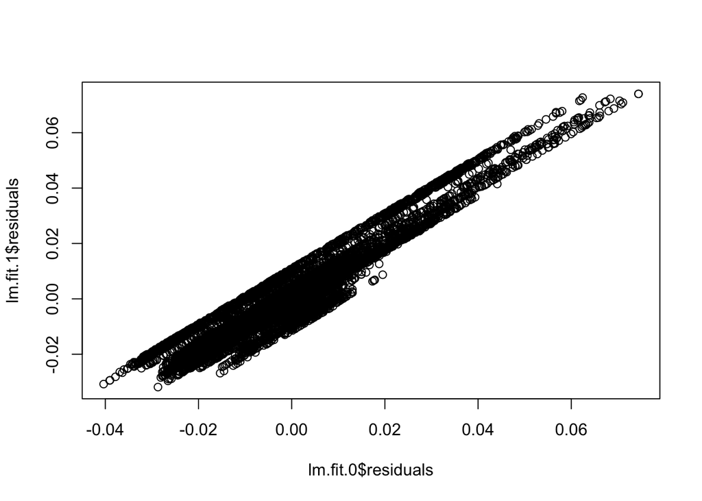

```r
# Plot a scatter plot of the residual's correlation
plot(lm.fit.0$residuals, lm.fit.1$residuals)
```

### ANOVA

Due to the complexity of the model, we only select a model that includes up to all two-way interaction terms called model 4 and compare it with a model that doesn’t include any interaction terms and call it model 3.

### Interpret the result

```
## Anova Table (Type III tests)
##
## Response: value.x
##                    Sum Sq    Df    F value    Pr(>F)
## (Intercept)        8.0142     1 38653.2586 < 2.2e-16 ***
## geo_value          0.1133    50    10.9254 < 2.2e-16 ***
## BarRestrict        0.0001     1     0.4728   0.49172
## OtherBusinessClose 0.0010     1     4.9465   0.02616 *
## RestaurantRestrict 0.0003     1     1.6622   0.19734
## StayAtHome         0.0007     1     3.3031   0.06918 .
## EmergDec           0.0804     1   387.7465 < 2.2e-16 ***
## GathRestrict       0.0091     1    43.9934  3.45e-11 ***
## NEBusinessClose    0.0000     1     0.1187   0.73046
## Residuals          2.2720 10958
## ---
## Signif. codes:  0 '***' 0.001 '**' 0.01 '*' 0.05 '.' 0.1 ' ' 1
```

```
## Note: model has aliased coefficients
##       sums of squares computed by model comparison
```

```
## Anova Table (Type III tests)
##
## Response: value.x
##                                        Sum Sq    Df F values    Pr(>F)
## geo_value                             0.04412    29   7.9222 < 2.2e-16 ***
## BarRestrict                           0.00000     0
## OtherBusinessClose                    0.00000     0
## RestaurantRestrict                    0.00000     0
## StayAtHome                            0.00000     0
## EmergDec                              0.00000     0
## GathRestrict                          0.00000     0
## NEBusinessClose                       0.00000     0
## geo_value:BarRestrict                 0.00000     0
## geo_value:OtherBusinessClose          0.00794    13   3.1804 8.559e-05 ***
## geo_value:RestaurantRestrict          0.00000     0
## geo_value:StayAtHome                  0.00881    35   1.3112    0.1034
## geo_value:EmergDec                    0.06801    49   7.2276 < 2.2e-16 ***
## geo_value:GathRestrict                0.02722    33   4.2946 2.631e-15 ***
## geo_value:NEBusinessClose             0.00052    16   0.1681    0.9999
## BarRestrict:OtherBusinessClose        0.00000     0
## BarRestrict:RestaurantRestrict        0.00000     0
## BarRestrict:StayAtHome                0.00000     0
## BarRestrict:EmergDec                  0.00000     0
## BarRestrict:GathRestrict              0.00000     0
## BarRestrict:NEBusinessClose           0.00000     0
## OtherBusinessClose:RestaurantRestrict 0.00000     0
## OtherBusinessClose:StayAtHome         0.00010     1   0.5008    0.4792
## OtherBusinessClose:EmergDec           0.00000     0
## OtherBusinessClose:GathRestrict       0.00000     0
## OtherBusinessClose:NEBusinessClose    0.00000     0
## RestaurantRestrict:StayAtHome         0.00000     0
## RestaurantRestrict:EmergDec           0.00000     0
## RestaurantRestrict:GathRestrict       0.00000     0
## RestaurantRestrict:NEBusinessClose    0.00000     0
## StayAtHome:EmergDec                   0.00000     0
## StayAtHome:GathRestrict               0.00000     1   0.0031    0.9557
## StayAtHome:NEBusinessClose            0.00003     1   0.1618    0.6876
## EmergDec:GathRestrict                 0.00000     0
## EmergDec:NEBusinessClose              0.00000     0
## GathRestrict:NEBusinessClose          0.00035     1   1.8474    0.1741
## Residuals                             2.06177 10736
## ---
## Signif. codes:  0 '***' 0.001 '**' 0.01 '*' 0.05 '.' 0.1 ' ' 1
```

### Model diagnostics

- Homogenity of variance
  - We see the model hardly satisify this assumption. By the Levine’s test, the variance across groups is statistically significantly different with the p-value is less than the significance level of 0.05.
- Normality assumption
  - Visually, the normality assumption is roughly satisfied based on the normal qq plot.

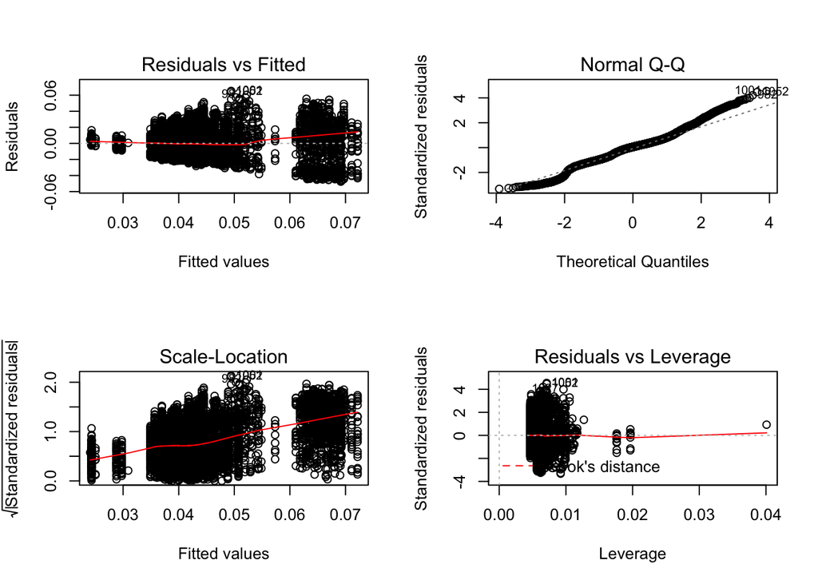

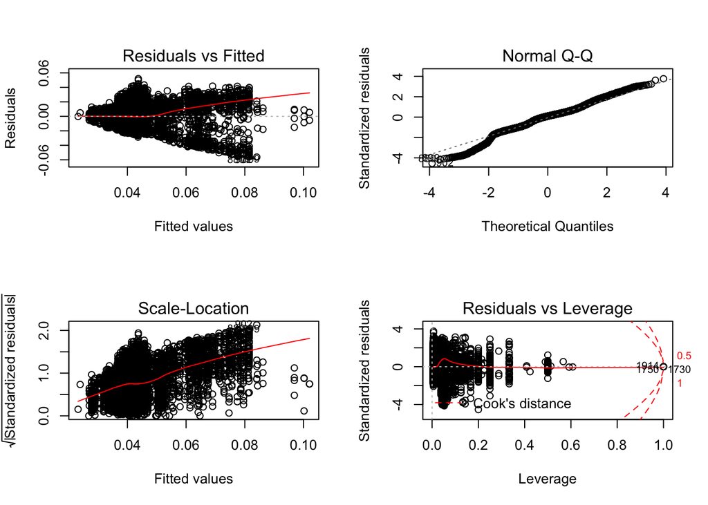

```
## Levene's Test for Homogeneity of Variance (center = median)
##          Df F value    Pr(>F)
## group   284   10.77 < 2.2e-16 ***
##       10731
## ---
## Signif. codes:  0 '***' 0.001 '**' 0.01 '*' 0.05 '.' 0.1 ' ' 1
```